# Confusion Matrix

Cecilia Fadhel

2025-08-06

last updated: August 07 2025

**Manuscript Title: Diet-responsive genetic determinants of intestinal colonization in the yeast *Candida albicans***

**Authors** Musfirat Shubaita1,2, Mazen Oneissi1, Elena Lindemann-Pérez1, Anne-Marie Krachler1,2, Cecilia Fadhel Alvarez1,2, Diana M. Proctor1,2, and J. Christian Pérez1,2*

**Affiliations** 1Department of Microbiology and Molecular Genetics, McGovern Medical School, The University of Texas Health Science Center at Houston, Houston, USA 2Graduate School of Biomedical Sciences, The University of Texas MD Anderson Cancer Center UTHealth Houston, Houston, USA

- Corresponding author E-mail jose.c.perez@uth.tmc.edu

Description of the dataset:

This script contains the code to generate a confusion matrix and decide which data will be used for subsequent analyses: forward or merged reads. This is established based on presense and absense of genera in each data set.

```r
library(knitr)
opts_chunk$set(fig.width=12, fig.height=8,
               echo=TRUE, warning=FALSE, message=FALSE, error = FALSE)
```

First, load R packages or install, if necessary.

```r
# Install/load packages
required_packages <- c("readxl", "dplyr", "tidyr", "VennDiagram", "phyloseq", "tibble")

for (pkg in required_packages) {
  if (!requireNamespace(pkg, quietly = TRUE)) {
    install.packages(pkg)
  }
  library(pkg, character.only = TRUE)
}
```

Load your phyloseq object (skip if already loaded)

```r
# Use load("your_phyloseq_object.RData") for an RData file  # or use readRDS("file.rds") for a phyloseq
ps <- readRDS("C:/Users/cfadhelalvarez/Desktop/perez_diet/rds_objects/PerezDiet_merged_Len250_EE5_5_RefSeq.rds")
```

Now, we extract taxonomy and build a table with the sequences to blast and empty columns to input the blast results.

```r
# Extract taxonomy table from phyloseq
taxa <- as.data.frame(tax_table(ps))

# Add sequences as a column (assumes rownames are sequences)
taxa <- taxa %>% rownames_to_column(var = "Sequence")

# Filter for rows with genus assigned
taxa_genus <- taxa %>%
  filter(!is.na(Genus), Genus != "") %>%
  group_by(Genus) %>%
  slice(1) %>%
  ungroup()

# Create table with genus and empty BLAST columns
blast_table <- taxa_genus %>%
  select(Sequence, Genus) %>%
  mutate(
    Top_BLAST_Hit = "",
    Alternative_Hit = ""
  )

# Optional – Save initial version
write.csv(blast_table, "C:/Users/cfadhelalvarez/Desktop/perez_diet/tables/empty_BLAST_table_PerezDiet_merged_Len250_EE5_5.csv", row.names = FALSE)
```

Manually add BLAST results or do it outside of R and read in table (if so, skip this step).

```r
# Manually add BLAST results or do it outside of R and read in table (if so, skip this step).
blast_table$Top_BLAST_Hit[1] <- "Bacteroides thetaiotaomicron"
blast_table$Alternative_Hit[1] <- "Bacteroides xylanisolvens"

# Save final version
write.csv(blast_table, "C:/Users/cfadhelalvarez/Desktop/perez_diet/tables/BLAST_table_PerezDiet_merged_Len250_EE5_5.csv", row.names = FALSE)
```

If starting from the BLAST table: Read in the Excel files (Sheet 2 has names only without match percentages)

```r
# Read in tables
forward_df <- read_excel("C:/Users/cfadhelalvarez/Desktop/perez_diet/tables/BLAST_table_PerezDiet_forward_Len250_f5_rNULL.xlsx", sheet = 2)
merged_df <- read_excel("C:/Users/cfadhelalvarez/Desktop/perez_diet/tables/BLAST_table_PerezDiet_merged_Len250_EE5_5.xlsx", sheet = 2)

# Extract genus names from BLAST columns only
extract_blast_genera <- function(df) {
  unique(na.omit(c(df$Top_BLAST_Hit, df$Alternative_Hit)))
}

forward_genera <- extract_blast_genera(forward_df)
merged_genera <- extract_blast_genera(merged_df)
```

Now you can create the confusion matrix showing the presense and absense of genera.

```r
# Create a confusion matrix (presence/absence)
all_genera <- sort(unique(c(forward_genera, merged_genera)))

confusion_matrix <- data.frame(
  Genus = all_genera,
  Present_in_Merged = ifelse(all_genera %in% merged_genera, "1", "0"),
  Present_in_Forward = ifelse(all_genera %in% forward_genera, "1", "0")
)

# Map genera to OTUs (based on BLAST assignments only)
get_blast_genus_to_otus <- function(df, dataset_label) {
  df_long <- df %>%
    select(Sequence, Top_BLAST_Hit, Alternative_Hit) %>%
    pivot_longer(cols = c(Top_BLAST_Hit, Alternative_Hit),
                 names_to = "BLAST_Type", values_to = "Genus") %>%
    filter(!is.na(Genus)) %>%
    distinct(Genus, Sequence)

  df_long %>%
    group_by(Genus) %>%
    summarise(OTUs = paste(unique(Sequence), collapse = ", "), .groups = "drop") %>%
    rename(!!paste0(dataset_label, "_OTUs") := OTUs)
}

merged_map <- get_blast_genus_to_otus(merged_df, "Merged")
forward_map <- get_blast_genus_to_otus(forward_df, "Forward")

# Combine OTU trace info
otu_trace_matrix <- full_join(merged_map, forward_map, by = "Genus") %>%
  arrange(Genus)
```

You can visualize this by creating a Venn Diagram.

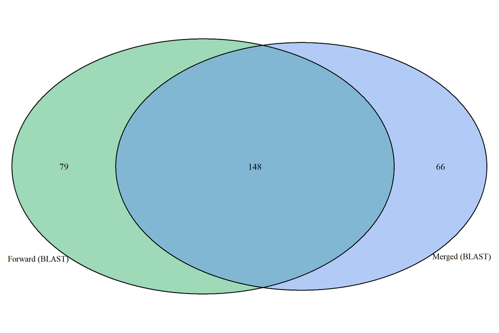

```r
# Create Venn Diagram
venn.plot <- draw.pairwise.venn(
  area1 = length(merged_genera),
  area2 = length(forward_genera),
  cross.area = length(intersect(merged_genera, forward_genera)),
  category = c("Merged (BLAST)", "Forward (BLAST)"),
  fill = c("cornflowerblue", "mediumseagreen"),
  alpha = c(0.5, 0.5),
  cex = 1.3,
  cat.cex = 1.2
)
```

```r
# Optional: Inspect genera found only in one or both datasets
only_forward <- filter(confusion_matrix, Present_in_Forward == "1", Present_in_Merged == "0")
only_merged  <- filter(confusion_matrix, Present_in_Forward == "0", Present_in_Merged == "1")
in_both      <- filter(confusion_matrix, Present_in_Forward == "1", Present_in_Merged == "1")

# Optional: Export tables (if not exported already)
write.csv(confusion_matrix, "C:/Users/cfadhelalvarez/Desktop/perez_diet/tables/genus_confusion_matrix_blast_only.csv", row.names = FALSE)
write.csv(otu_trace_matrix, "C:/Users/cfadhelalvarez/Desktop/perez_diet/tables/genus_to_otus_trace_blast_only.csv", row.names = FALSE)
```